# Project Business Statistics: E-news Express

## 3. Is the conversion and preferred language are independent or related?

#### Perform Visual Analysis

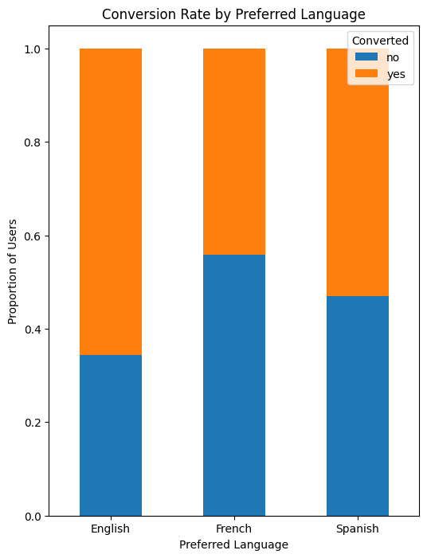

```python
# Visualize normalized counts to see proportions
pd.crosstab(df['language_preferred'], df['converted'], normalize='index').plot(kind='bar', stacked=True, figsize=(6, 8))
plt.title('Conversion Rate by Preferred Language')
plt.xlabel('Preferred Language')
plt.ylabel('Proportion of Users')
plt.xticks(rotation=0)
plt.legend(title='Converted')
plt.show()
```

From the visual analysis, it seems there might be some differences in conversion rates across languages.

#### Step 1: Define the null and alternate hypotheses

$H_0$: Conversion status is independent of the preferred language.

$H_a$: Conversion status and preferred language are related (dependent).

#### Step 2: Select Appropriate test

Since we are examining the relationship between two categorical variables ('converted' and 'language_preferred'), the appropriate statistical test is the Chi-Squared test for independence.

#### Step 3: Decide the significance level

As stated in the problem description, the significance level ($\alpha$) is 5%.

$\alpha = 0.05$

#### Step 4: Collect and prepare data

Created the contingency table. This table is the required data structure for the Chi-Squared test.

```python
# Contingency table created in the visual analysis step
contingency_table = pd.crosstab(df['language_preferred'], df['converted'])
print("Contingency Table:")
print(contingency_table)
```

```
Contingency Table:
converted           no  yes
language_preferred
English             11   21
French              19   15
Spanish             16   18
```

#### Step 5: Calculate the p-value

```python
# Import the required function
from scipy.stats import chi2_contingency

# Perform the Chi-Squared test
chi2_stat, p_value, dof, expected = chi2_contingency(contingency_table)
print(f"P-value: {p_value:.4f}")
```

```
P-value: 0.2130
```

#### Step 6: Compare the p-value with 𝛼

```python
# Significance level
alpha = 0.05

print(f"The p-value is: {p_value:.4f}")
print(f"The significance level α is: {alpha}")

# Compare p-value and alpha
if p_value < alpha:
  print("Since the p-value (", p_value, ") is less than the significance level (", alpha, "), we reject the null hypothesis.")
else:
  print("Since the p-value (", p_value, ") is greater than the significance level (", alpha, "), we fail to reject the null hypothesis.")
```

```
The p-value is: 0.2130
The significance level α is: 0.05
Since the p-value ( 0.2129888748754345 ) is greater than the significance level ( 0.05 ), we fail to reject the null hypothesis.
```

#### Step 7: Draw inference

Based on the comparison in the previous step:

p-value (calculated value from step 5) compared to alpha (0.05).

Decision: Based on whether the p-value is less than or greater than alpha.

Interpretation:

- If p-value < $\alpha$: Reject $H_0$. There is sufficient statistical evidence to conclude that conversion status and preferred language are related.
- If p-value > $\alpha$: Fail to reject $H_0$. There is not enough statistical evidence to conclude that conversion status and preferred language are related.

```python
print("Inference:")
if p_value < alpha:
    print(f"Since the p-value ({p_value:.4f}) is less than the significance level ({alpha}), we reject the null hypothesis.")
    print("This means there is statistically significant evidence to conclude that conversion status depends on the preferred language.")
else:
    print(f"Since the p-value ({p_value:.4f}) is greater than the significance level ({alpha}), we fail to reject the null hypothesis.")
    print("This means there is not enough statistical evidence to conclude that conversion status depends on the preferred language.")
```

```
Inference:
Since the p-value (0.2130) is greater than the significance level (0.05), we fail to reject the null hypothesis.
This means there is not enough statistical evidence to conclude that conversion status depends on the preferred language.
```

## 4. Is the time spent on the new page same for the different language users?

#### Perform Visual Analysis

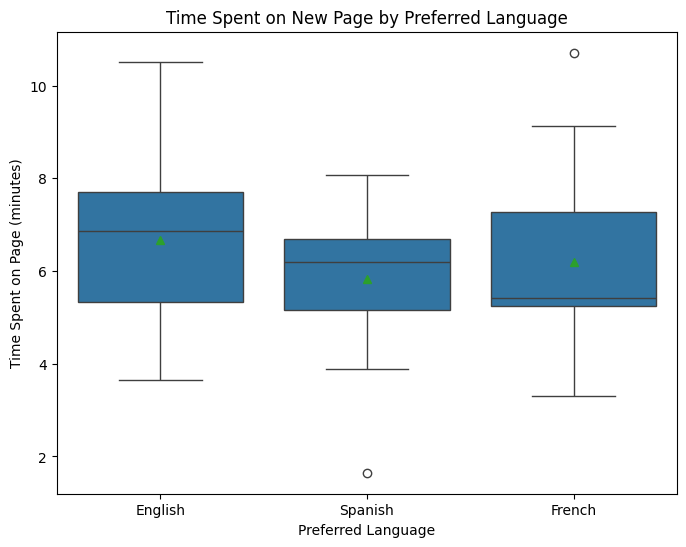

```python
# Filter data for only the new landing page
df_new_page = df[df['landing_page'] == 'new']

# Visualize the time spent on the new page by language
plt.figure(figsize=(8, 6))
sns.boxplot(x='language_preferred', y='time_spent_on_the_page', showmeans = True, data=df_new_page)
plt.title('Time Spent on New Page by Preferred Language')
plt.xlabel('Preferred Language')
plt.ylabel('Time Spent on Page (minutes)')
plt.show()
```

- The boxplot shows the distribution of time spent on the new page for each language. Visually, there seem to be some differences in the median and spread of time spent among the language groups.

```python
# calculate the mean time spent on the new page for different language users
df_new_page.groupby(['language_preferred'])['time_spent_on_the_page'].mean()
```

| language_preferred | time_spent_on_the_page |
| --- | --- |
| English | 6.663750 |
| French | 6.196471 |
| Spanish | 5.835294 |

**dtype:** float64

#### Step 1: Define the null and alternate hypotheses

$H_0$: The mean time spent on the new landing page is the same for users of all preferred languages

($\mu_{\text{English, new}} = \mu_{\text{French, new}} = \mu_{\text{Spanish, new}}$).

$H_a$: The mean time spent on the new landing page is not the same for all preferred languages (at least one mean is different).

#### Step 2: Select Appropriate test

Since we are comparing the means of a numerical variable across three independent groups, the appropriate statistical test is the one-way Analysis of Variance (ANOVA).

#### Step 3: Decide the significance level

As stated in the problem description, the significance level ($\alpha$) is 5%.

$\alpha = 0.05$

#### Step 4: Collect and prepare data

```python
# Filter data for only the new landing page
df_new_page = df[df['landing_page'] == 'new']

# Separate time spent data by language for the new page
time_spent_english_new = df_new_page[df_new_page['language_preferred'] == 'English']['time_spent_on_the_page']
time_spent_french_new = df_new_page[df_new_page['language_preferred'] == 'French']['time_spent_on_the_page']
time_spent_spanish_new = df_new_page[df_new_page['language_preferred'] == 'Spanish']['time_spent_on_the_page']

# Print the number of observations in each group
print(f"Number of English users on new page: {len(time_spent_english_new)}")
print(f"Number of French users on new page: {len(time_spent_french_new)}")
print(f"Number of Spanish users on new page: {len(time_spent_spanish_new)}")
```

```
Number of English users on new page: 16
Number of French users on new page: 17
Number of Spanish users on new page: 17
```

#### Step 5: Check ANOVA Assumptions

The assumptions for a One-Way ANOVA test are:

1. The responses for each factor level (language groups) have a normal population distribution.
2. These distributions have the same variance (homogeneity of variances).
3. The data are independent. Which is true from our dataset.

We can check the first two assumptions staistically by using Shapiro-Wiki test and Levene test respectively.

#### Checking normality using Shapiro-Wiki test

```python
# Import the required function for Shapiro-Wilk test
from scipy.stats import shapiro

# Perform Shapiro-Wilk test for English group
shapiro_english_stat, shapiro_english_p_value = shapiro(time_spent_english_new)
print(f"Shapiro-Wilk Test (English - New Page): Statistic={shapiro_english_stat:.4f}, p-value={shapiro_english_p_value:.4f}")
if shapiro_english_p_value < alpha:
    print("The English group data does not appear to be normally distributed.")
else:
    print("The English group data appears to be normally distributed.")

# Perform Shapiro-Wilk test for French group
shapiro_french_stat, shapiro_french_p_value = shapiro(time_spent_french_new)
print(f"\nShapiro-Wilk Test (French - New Page): Statistic={shapiro_french_stat:.4f}, p-value={shapiro_french_p_value:.4f}")
if shapiro_french_p_value < alpha:
    print("The French group data does not appear to be normally distributed.")
else:
    print("The French group data appears to be normally distributed.")

# Perform Shapiro-Wilk test for Spanish group
shapiro_spanish_stat, shapiro_spanish_p_value = shapiro(time_spent_spanish_new)
print(f"\nShapiro-Wilk Test (Spanish - New Page): Statistic={shapiro_spanish_stat:.4f}, p-value={shapiro_spanish_p_value:.4f}")
if shapiro_spanish_p_value < alpha:
    print("The Spanish group data does not appear to be normally distributed.")
else:
    print("The Spanish group data appears to be normally distributed.")
```

```
Shapiro-Wilk Test (English - New Page): Statistic=0.9731, p-value=0.8863
The English group data appears to be normally distributed.

Shapiro-Wilk Test (French - New Page): Statistic=0.9403, p-value=0.3214
The French group data appears to be normally distributed.

Shapiro-Wilk Test (Spanish - New Page): Statistic=0.9073, p-value=0.0901
The Spanish group data appears to be normally distributed.
```

#### Check for Homogeneity of Variances using Levene's test

```python
# Check for Homogeneity of Variances using Levene's test
from scipy.stats import levene

levene_test_stat, levene_p_value = levene(time_spent_english_new, time_spent_french_new, time_spent_spanish_new)

print(f"Levene's Test Statistic: {levene_test_stat:.4f}")
print(f"Levene's p-value: {levene_p_value:.4f}")

if levene_p_value < alpha:
    print("Levene's test suggests that the variances are significantly different. This may violate an ANOVA assumption.")
else:
    print("Levene's test suggests that the variances are not significantly different. The homogeneity of variance assumption appears to be met.")
```

```
Levene's Test Statistic: 0.7736
Levene's p-value: 0.4671
Levene's test suggests that the variances are not significantly different. The homogeneity of variance assumption appears to be met.
```

#### Step 6: Calculate the p-value

```python
# Import the required function
from scipy.stats import f_oneway

# Perform the one-way ANOVA test
f_statistic, p_value = f_oneway(time_spent_english_new, time_spent_french_new, time_spent_spanish_new)

print(f"P-value: {p_value:.4f}")
```

```
P-value: 0.4320
```

#### Step 7: Compare the p-value with 𝛼

```python
# Significance level
alpha = 0.05

print(f"The p-value is: {p_value:.4f}")
print(f"The significance level α is: {alpha}")

# Compare p-value and alpha
if p_value < alpha:
  print("Since the p-value (", p_value, ") is less than the significance level (", alpha, "), we reject the null hypothesis.")
else:
  print("Since the p-value (", p_value, ") is greater than the significance level (", alpha, "), we fail to reject the null hypothesis.")
```

```
The p-value is: 0.4320
The significance level α is: 0.05
Since the p-value ( 0.43204138694325955 ) is greater than the significance level ( 0.05 ), we fail to reject the null hypothesis.
```

#### Step 8: Draw inference

Based on the comparison in the previous step:

p-value (calculated value from step 6) compared to alpha (0.05).

Decision: Based on whether the p-value is less than or greater than alpha.

Interpretation:

- If p-value < $\alpha$: Reject $H_0$. There is sufficient statistical evidence to conclude that the mean time spent on the new landing page is different for at least one preferred language group.
- If p-value >= $\alpha$: Fail to reject $H_0$. There is not enough statistical evidence to conclude that the mean time spent on the new landing page is different for the different language groups.

```python
print("Inference:")
if p_value < alpha:
    print(f"Since the p-value ({p_value:.4f}) is less than the significance level ({alpha}), we reject the null hypothesis.")
    print("This means there is statistically significant evidence to conclude that the mean time spent on the new page is NOT the same for the different language users.")
    print("Note: To find which specific language groups differ, a post-hoc test (like Tukey's HSD) would be needed.")
else:
    print(f"Since the p-value ({p_value:.4f}) is greater than the significance level ({alpha}), we fail to reject the null hypothesis.")
    print("This means there is not enough statistical evidence to conclude that the mean time spent on the new page is different for the different language users.")
```

```
Inference:
Since the p-value (0.4320) is greater than the significance level (0.05), we fail to reject the null hypothesis.
This means there is not enough statistical evidence to conclude that the mean time spent on the new page is different for the different language users.
```

## Conclusion and Business Recommendations

Based on the statistical analysis performed, here are the key findings and business recommendations for E-news Express: